# PSP App User Guide

[figure not shown]

This guide will provide documentation on some of the available functions in the application. The following sections describe the various ways to view, filter and maneuver around the data to aide in analysis.

# Navbar

[figure not shown]

The navbar allows users to navigate between the data analysis and reference information panes. Click on “Data Summaries” or “References” to choose which pane is active. Any changes to your parameter selections will not be lost while navigating between navbar panes.

Clicking on the title, “Pesticide Stewardship Partnerships”, will open a new window with the main PSP project page on the Oregon Department of Agriculture website.

## Data Analysis

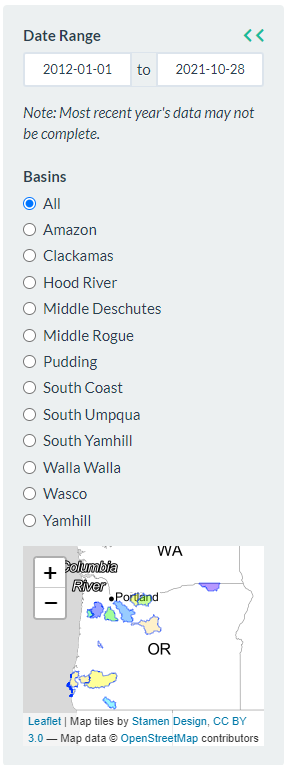

The sidebar allows users to filter the data shown in the data analysis panes. To hide the sidebar, click the button. The following sections describe the inputs available in the sidebar.

#### Date Range

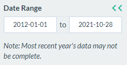

Users can use the date range input to choose the start date and end date that are used to filter the data used within the data analysis panes. Click on the start date or end date windows to open the calendar and choose a date.

#### Basin

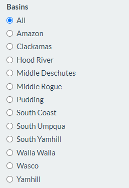

Click on a basin to focus the data on for analyis. All of the data will be filtered for the selected basin. A map of the basin will appear on the bottom of the sidebar.

### Plots

The app includes various plots that allow the data to be viewed based on different parameters. Most of these plots include some interactive functions described in the following sections.

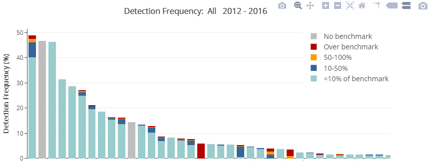

#### Hover

Hovering over the data on the plots will show data related to the bars or points nearest the cursor. Stacked bar charts will show the data of each bar related to that x-axis value.

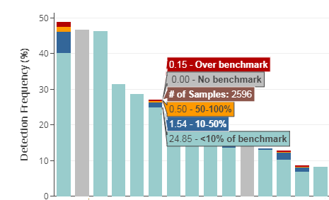

#### Editing Plots

##### Titles

Titles can be edited by clicking on the title and entering the desired text. Adding “< b >” before and “< /b >” (with the spaces removed) after your text will attach a bold font.

##### Axes

Click and drag on either the x or y axis to move the plot view along the chosen axis. Click and drag on either end of the axis to move only that end of the axis. Clicking on either end of an axis will give the option to change the value of the limit of that end of the axis. *Note: if the axis contains text values, the value will be the nth value in the arrangement of the axis.*

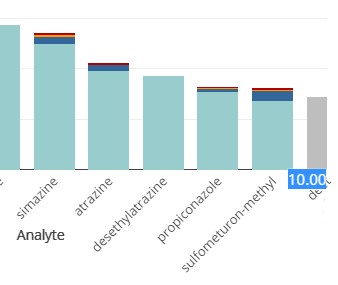

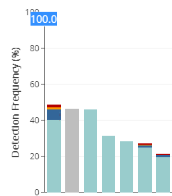

##### Legends

Clicking on the legend titles will allow for the text to be changed. Clicking the color or symbol associated with the series will turn it “off”, removing its visibility on the plot (shown with semi-transparent legend entry). Clicking it again turn the series back on.

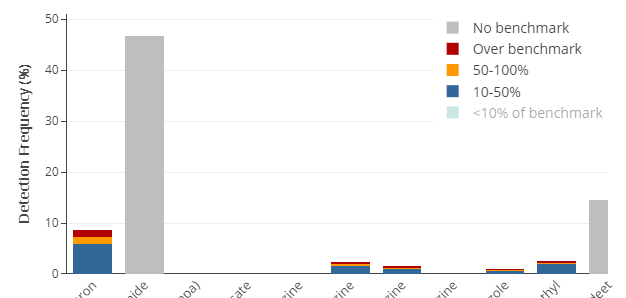

##### Hover Bar

With the cursor hovering over the plot, a toolbar will appear at the top right of the plot window. The most notable features in this bar are the two camera buttons that will download the current view of the plot to your computer.

### Detection Map

The detection map displays pesticide detection data spatially and contains multiple layers that allow the user to compare the results based on location, estimated crop types, etc. Use the drop down boxes to choose the analyte and aquatic life ratio range to display on the map.

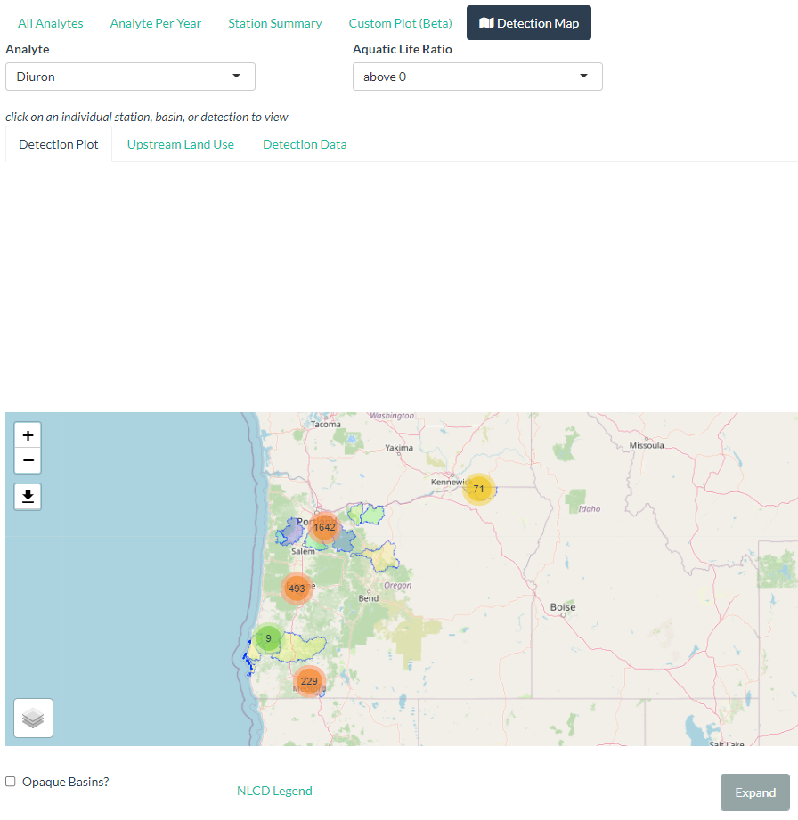

The basins selected via the sidebar will be displayed on the map along with detections that match the selections from the drop down list. To see the available layers to add or remove, click on the symbol. Check the boxes of the desired layers and they will be added to the map.

If there are many detections within a certain area, they will be grouped together with a circle marker containing their sum total of detections. Clicking on the marker will zoom to the extent of those detections. Detections will be grouped until they can be separated by monitoring station.

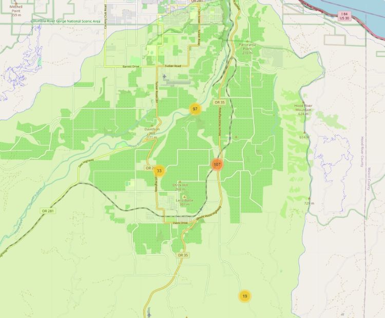

At this point, clicking on a circle will produce a plot of the detection at that station above the map in the Detection Plot tab.

#### Subplots

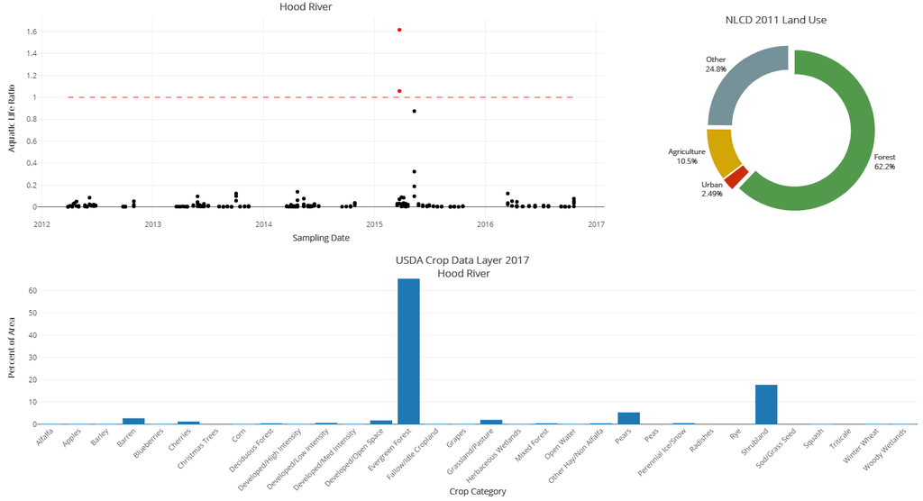

#### Layers

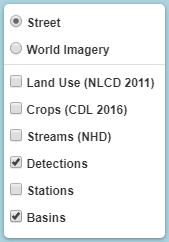

*Note: clearcuts may be classified as shrubland or grassland due to its vegetation heights and will be included in the “other” catagory in the land use summary charts. This may cause an underestimation of the percent of forest land.*

## References

The Reference section of the Navbar provides some helpful information to support the data analysis and add context to the results. The glossary of terms provides general definitions of some of the vocabulary used throughout the app with equations for calculations or links for sources and/or more information. The analyte descriptions give some general info on the more common pollutant ingredients detected throughout the PSPs. There is also an additional station reference section that provides a lookup table to search for station IDs, descriptions or associated project basin.